# Demanda de Dinero en Canadá

Liquidez, Producto e Interés — Ayudantía 10/11

Max V.

17 de mayo, 2026

# 1 Introducción

Este notebook es un **estudio descriptivo e inferencial** de la interacción entre el PIB canadiense y su mercado de dinero. Se trabaja con datos trimestrales de Canadá extraídos de la *Tabla 17.3 de Econometría* de Gujarati D., disponibles públicamente en GitHub.

El análisis cubre:

1. Carga y descripción del dataset.
2. Transformación y construcción de variables derivadas (logaritmos, rezagos, inflación).
3. Análisis exploratorio de datos (EDA) — series de tiempo y dispersión.
4. Modelado de la demanda de dinero mediante MCO.
5. Diagnóstico de supuestos del modelo lineal clásico.

Este trabajo fue realizado como trabajo de clase en la asignatura de Econometría 1 para estudiantes de Ingeniería Comercial, priorizando el uso de Rstudio como herramienta de EDA y su uso para estudio de fenómenos económicos. La autoría de este material es de M. Vera. —

# 2 Configuración del entorno

```r
library(tidyverse)   # ggplot2, dplyr, tidyr, readr, lubridate
library(ggthemes)    # Paletas y temas adicionales
library(kableExtra)  # Tablas estilizadas
library(lmtest)      # Pruebas de heterocedasticidad y autocorrelación
library(car)         # Pruebas de multicolinealidad y normalidad (ncvTest)
library(tseries)     # Pruebas de raíz unitaria y Jarque-Bera
```

# 3 Carga de datos

Los datos se leen directamente desde el repositorio de GitHub del autor, evitando dependencias de rutas locales.

```r
raw_url <- "https://raw.githubusercontent.com/maxvv-levtcl/Portafolio-de-proyectos/refs/heads/main/fuentes%20de%20datos/Money%20demand%20canada.csv"

Canada_Md <- read_csv(raw_url)
```

## 3.1 Descripción de variables

```r
vectores <- colnames(Canada_Md)

df_info <- data.frame(
  Variable = vectores,
  Descripción = c(
    "Periodo de observación (trimestral)",
    "Millones de dólares canadienses en circulación (M1)",
    "Tasa de interés corporativa a 90 días",
    "Deflactor implícito del PIB",
    "Producto Interno Bruto nominal"
  )
)

kable(df_info,
      caption = "Demanda de dinero en Canadá — Variables en estudio",
      align   = c("l", "l")) %>%
  kable_styling(bootstrap_options = c("striped", "hover", "condensed"),
                full_width = FALSE)
```

Demanda de dinero en Canadá — Variables en estudio

| Variable | Descripción |
| --- | --- |
| obs | Periodo de observación (trimestral) |
| M1 | Millones de dólares canadienses en circulación (M1) |
| R | Tasa de interés corporativa a 90 días |
| P | Deflactor implícito del PIB |
| GDP | Producto Interno Bruto nominal |

# 4 Transformación de variables

Se construyen las variables transformadas necesarias para el análisis econométrico:

- **Logaritmos** de M1, PIB real y tasa de interés (para interpretar elasticidades directamente).
- **Rezagos** de primer orden sobre el deflactor y la tasa de interés.
- **Tasa de inflación** aproximada como variación logarítmica del deflactor.
- Versiones **reescaladas** de M1, PIB y la tasa para facilitar la visualización conjunta.

```r
Modelo_Equilibrio <- Canada_Md %>%
  mutate(across(all_of(vectores), as.numeric)) %>%
  # Corrección de escala en R (algunos valores aparecen en base 100.000)
  mutate(R_CLEAN = ifelse(R >= 100, R / 100000, R)) %>%
  mutate(
    L        = log(M1),
    y        = log(GDP / P),          # PIB real en logaritmo
    l_R      = log(R),
    l_P      = log(P),
    R_rez    = lag(l_R, n = 1),
    P_rez    = lag(l_P, n = 1),
    T_infl   = (l_P - P_rez) / P_rez, # Tasa de inflación aproximada
    M1_cientos = M1 / 100,
    GDP_Miles  = GDP / 1000,
    GDP_100K   = GDP / 100000,
    R_Decimos  = R / 10
  ) %>%
  mutate(fecha = yq(Canada_Md$obs)) %>%
  select(
    fecha, M1, P, GDP, L, y, l_R, l_P, P_rez, R_rez,
    T_infl, R = R_CLEAN, M1_cientos, GDP_Miles, GDP_100K, R_Decimos
  )

head(Modelo_Equilibrio)
```

| fecha | M1 | P | GDP | L | y | l_R | l_P | P_rez | R_rez | T_infl | R | M1_cientos | GDP_Miles | GDP_100K | R_Decimos |
| --- | --- | --- | --- | --- | --- | --- | --- | --- | --- | --- | --- | --- | --- | --- | --- |
| 1979-01-01 | 22175.00 | 0.77947 | 334800 | 10.00672 | 12.97043 | 2.409943 | -0.2491411 | NA | NA | NA | 11.13333 | 221.7500 | 334.800 | 3.34800 | 1.113333 |
| 1979-04-01 | 22841.00 | 0.80861 | 336708 | 10.03631 | 12.93941 | 2.412933 | -0.2124386 | -0.2491411 | 2.409943 | -0.1473162 | 11.16667 | 228.4100 | 336.708 | 3.36708 | 1.116667 |
| 1979-07-01 | 23461.00 | 0.82649 | 340096 | 10.06309 | 12.92755 | 2.468100 | -0.1905675 | -0.2124386 | 2.412933 | -0.1029526 | 11.80000 | 234.6100 | 340.096 | 3.40096 | 1.180000 |
| 1979-10-01 | 23427.00 | 0.84863 | 341844 | 10.06164 | 12.90624 | 2.652067 | -0.1641320 | -0.1905675 | 2.468100 | -0.1387197 | 14.18333 | 234.2700 | 341.844 | 3.41844 | 1.418333 |
| 1980-01-01 | 23811.00 | 0.86693 | 342776 | 10.07790 | 12.88763 | 2.666070 | -0.1427970 | -0.1641320 | 2.652067 | -0.1299865 | 14.38333 | 238.1100 | 342.776 | 3.42776 | 1.438333 |
| 1980-04-01 | 23612.33 | 0.88950 | 342264 | 10.06952 | 12.86043 | 2.563664 | -0.1170958 | -0.1427970 | 2.666070 | -0.1799846 | 12.98330 | 236.1233 | 342.264 | 3.42264 | 1.298330 |

# 5 Análisis Exploratorio de Datos (EDA)

## 5.1 Distribución del dinero en circulación (M1)

El boxplot permite identificar la dispersión central y posibles valores atípicos de M1 a lo largo del período muestral.

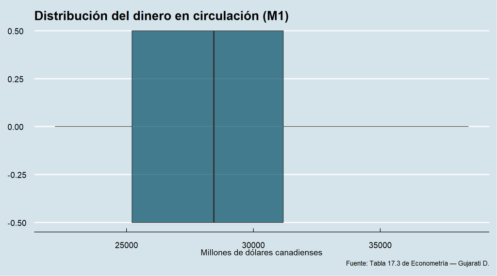

```r
ggplot(Modelo_Equilibrio, aes(x = M1)) +
  geom_boxplot(
    fill         = ggthemes::economist_pal()(1),
    alpha        = 0.7,
    width        = 1,
    outlier.shape = NA
  ) +
  labs(
    title   = "Distribución del dinero en circulación (M1)",
    x       = "Millones de dólares canadienses",
    caption = "Fuente: Tabla 17.3 de Econometría — Gujarati D."
  ) +
  theme_economist()
```

## 5.2 Series de tiempo: M1 y PIB

Se grafican el efectivo en circulación (M1, en cientos) y el PIB nominal (en miles) para visualizar su evolución conjunta a lo largo del tiempo. Se usaron variables fraccionadas para favorecer la visibilidad sin tener que entrar en tecnisismos de gráficos.

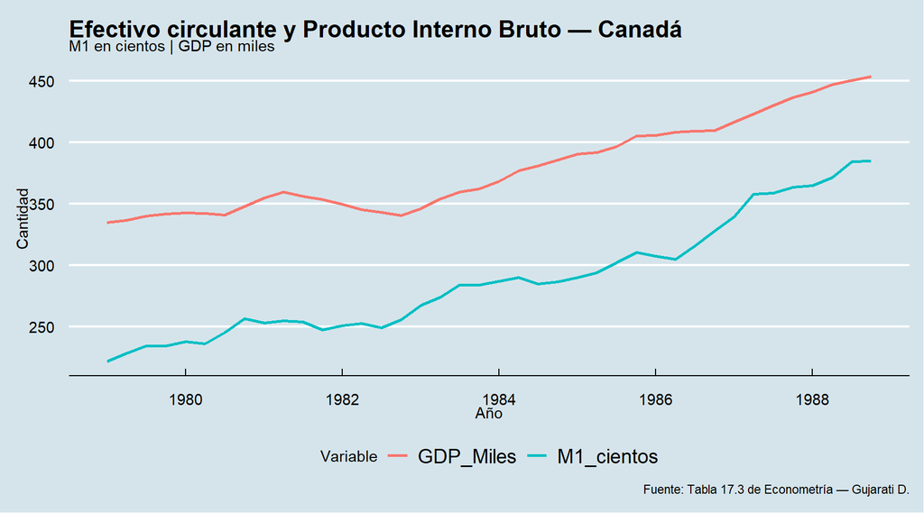

```r
datos_prod <- Modelo_Equilibrio %>%
  pivot_longer(
    cols      = c(M1_cientos, GDP_Miles),
    names_to  = "historico",
    values_to = "desempeño"
  )

ggplot(datos_prod, aes(x = fecha, y = desempeño, color = historico)) +
  geom_line(size = 1) +
  labs(
    title    = "Efectivo circulante y Producto Interno Bruto — Canadá",
    subtitle = "M1 en cientos | GDP en miles",
    x        = "Año",
    y        = "Cantidad",
    color    = "Variable",
    caption  = "Fuente: Tabla 17.3 de Econometría — Gujarati D."
  ) +
  theme_economist() +
  theme(legend.position = "bottom")
```

## 5.3 Series de tiempo: Deflactor, PIB y Tasa de interés

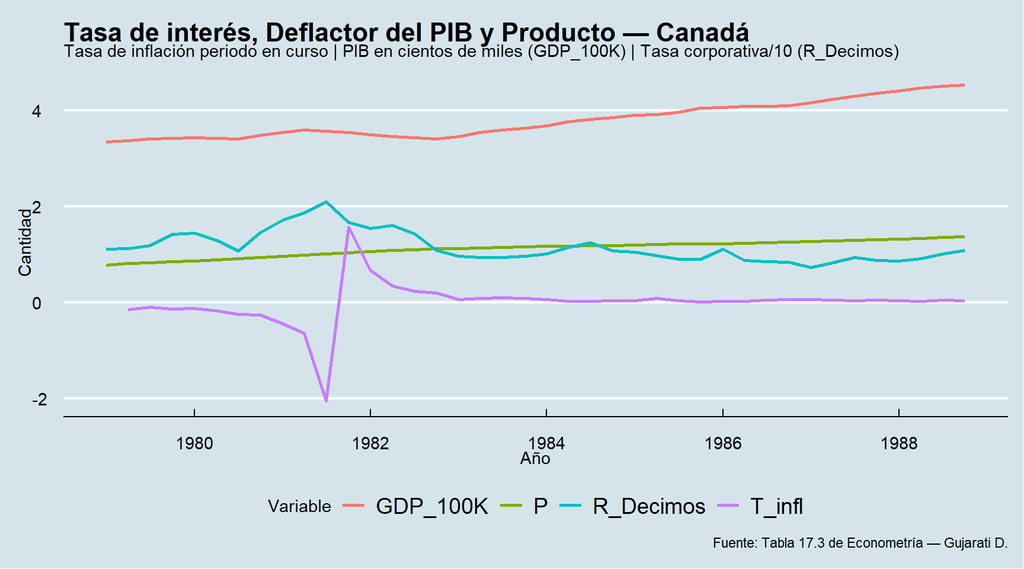

```r
datos_moneda <- Modelo_Equilibrio %>%
  pivot_longer(
    cols      = c(P, GDP_100K, R_Decimos, T_infl),
    names_to  = "nombres",
    values_to = "tasas"
  )

ggplot(datos_moneda, aes(x = fecha, y = tasas, color = nombres)) +
  geom_line(size = 1) +
  labs(
    title    = "Tasa de interés, Deflactor del PIB y Producto — Canadá",
    subtitle = "Tasa de inflación periodo en curso | PIB en cientos de miles (GDP_100K) | Tasa corporativa/10 (R_Decimos)",
    x        = "Año",
    y        = "Cantidad",
    color    = "Variable",
    caption  = "Fuente: Tabla 17.3 de Econometría — Gujarati D."
  ) +
  theme_economist() +
  theme(legend.position = "bottom")
```

# 6 Análisis de correlaciones — Scatterplots

Antes de estimar el modelo, exploramos visualmente las relaciones entre las variables en logaritmos.

## 6.1 M1 vs PIB Real

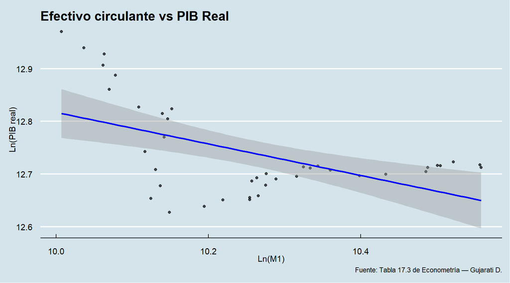

```r
ggplot(Modelo_Equilibrio, aes(x = L, y = y)) +
  geom_point(size = 1.5, alpha = 0.7) +
  geom_smooth(method = "lm", color = "blue", linewidth = 1, se = TRUE) +
  labs(
    title   = "Efectivo circulante vs PIB Real",
    x       = "Ln(M1)",
    y       = "Ln(PIB real)",
    caption = "Fuente: Tabla 17.3 de Econometría — Gujarati D."
  ) +
  theme_economist()
```

## 6.2 Tasa de interés vs M1

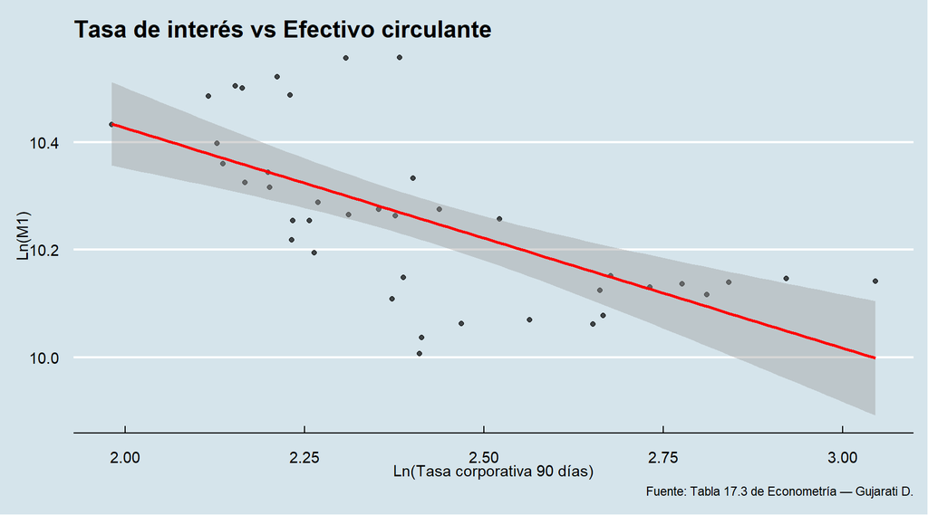

```r
ggplot(Modelo_Equilibrio, aes(x = l_R, y = L)) +
  geom_point(size = 1.5, alpha = 0.7) +
  geom_smooth(method = "lm", color = "red", linewidth = 1, se = TRUE) +
  labs(
    title   = "Tasa de interés vs Efectivo circulante",
    x       = "Ln(Tasa corporativa 90 días)",
    y       = "Ln(M1)",
    caption = "Fuente: Tabla 17.3 de Econometría — Gujarati D."
  ) +
  theme_economist()
```

## 6.3 Tasa de interés vs PIB Real

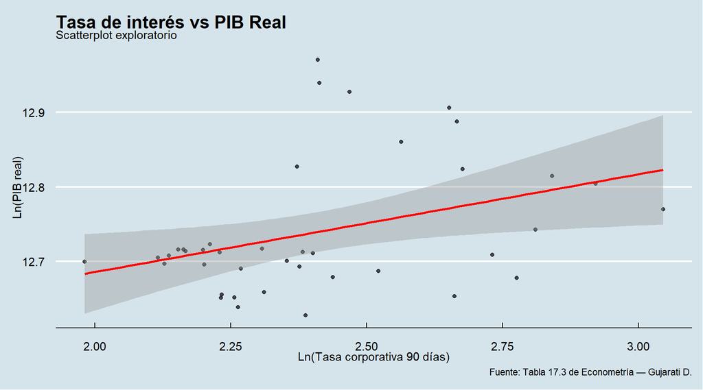

```r
ggplot(Modelo_Equilibrio, aes(x = l_R, y = y)) +
  geom_point(size = 1.5, alpha = 0.7) +
  geom_smooth(method = "lm", color = "red", linewidth = 1, se = TRUE) +
  labs(
    title    = "Tasa de interés vs PIB Real",
    subtitle = "Scatterplot exploratorio",
    x        = "Ln(Tasa corporativa 90 días)",
    y        = "Ln(PIB real)",
    caption  = "Fuente: Tabla 17.3 de Econometría — Gujarati D."
  ) +
  theme_economist()
```

# 7 Modelo de Demanda de Dinero (MCO)

## 7.1 Estimación

Se estima el modelo de equilibrio en el mercado de dinero:

$$\ln(y_t) = \beta_0 + \beta_1 \ln(M1_t) +
\varepsilon_t$$

donde $y$ es el PIB real y $L = \ln(M1)$.

```r
Eq_Mdmnd <- lm(y ~ L, data = Modelo_Equilibrio)
summary(Eq_Mdmnd)
```

```
##
## Call:
## lm(formula = y ~ L, data = Modelo_Equilibrio)
##
## Residuals:
##       Min        1Q    Median        3Q       Max
## -0.145048 -0.053838 -0.001329  0.050523  0.155490
##
## Coefficients:
##             Estimate Std. Error t value Pr(>|t|)
## (Intercept) 15.81081    0.79377   19.92  < 2e-16 ***
## L           -0.29939    0.07737   -3.87 0.000415 ***
## ---
## Signif. codes:  0 '***' 0.001 '**' 0.01 '*' 0.05 '.' 0.1 ' ' 1
##
## Residual standard error: 0.07631 on 38 degrees of freedom
## Multiple R-squared:  0.2827, Adjusted R-squared:  0.2638
## F-statistic: 14.97 on 1 and 38 DF,  p-value: 0.000415
```

```r
cat("Media de residuos:", round(mean(Eq_Mdmnd$residuals), 8))
```

```
## Media de residuos: 0
```

> **Interpretación:** El coeficiente de $\ln(M1)$ representa la **elasticidad del PIB real a la oferta de dinero**. Una media de residuos cercana a 0 es señal de que el modelo es insesgado en términos condicionales.

## 7.2 Pronóstico vs Observado

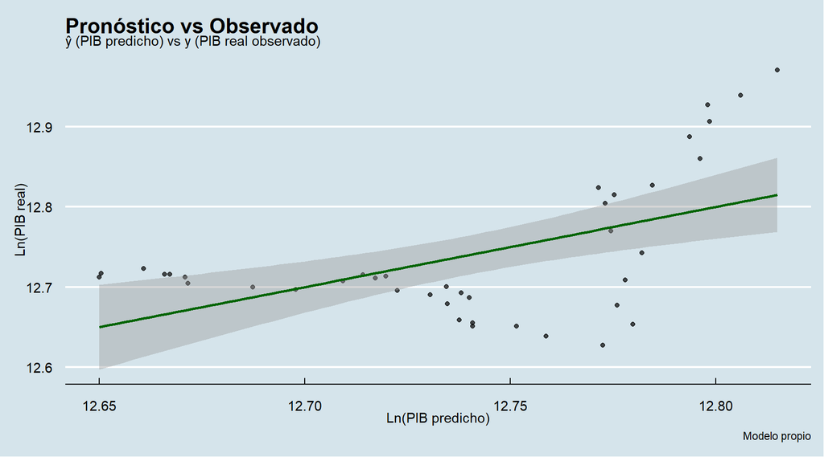

```r
y_hat <- predict(Eq_Mdmnd)

ggplot(Modelo_Equilibrio, aes(x = y_hat, y = y)) +
  geom_point(size = 1.5, alpha = 0.7) +
  geom_smooth(method = "lm", color = "darkgreen", linewidth = 1, se = TRUE) +
  labs(
    title    = "Pronóstico vs Observado",
    subtitle = "ŷ (PIB predicho) vs y (PIB real observado)",
    x        = "Ln(PIB predicho)",
    y        = "Ln(PIB real)",
    caption  = "Modelo propio"
  ) +
  theme_economist()
```

## 7.3 Modelo auxiliar: Deflactor ~ Tasa de interés

```r
val_mon1 <- lm(l_P ~ l_R, data = Modelo_Equilibrio)
summary(val_mon1)
```

```
##
## Call:
## lm(formula = l_P ~ l_R, data = Modelo_Equilibrio)
##
## Residuals:
##      Min       1Q   Median       3Q      Max
## -0.35149 -0.03129  0.02098  0.07918  0.20003
##
## Coefficients:
##             Estimate Std. Error t value Pr(>|t|)
## (Intercept)  0.97211    0.19651   4.947 1.57e-05 ***
## l_R         -0.36091    0.08108  -4.451 7.25e-05 ***
## ---
## Signif. codes:  0 '***' 0.001 '**' 0.01 '*' 0.05 '.' 0.1 ' ' 1
##
## Residual standard error: 0.1275 on 38 degrees of freedom
## Multiple R-squared:  0.3427, Adjusted R-squared:  0.3254
## F-statistic: 19.81 on 1 and 38 DF,  p-value: 7.253e-05
```

```r
cat("Media de residuos:", round(mean(val_mon1$residuals), 8), "\n")
```

```
## Media de residuos: 0
```

```r
cat("SCR (Suma de cuadrados de residuos):", round(sum(val_mon1$residuals^2), 6))
```

```
## SCR (Suma de cuadrados de residuos): 0.617636
```

# 8 Diagnóstico de supuestos del modelo lineal

## 8.1 1. Autocorrelación del error

Se aplican las pruebas de **Durbin-Watson** (orden 1) y **Breusch-Godfrey** (hasta orden 4).

- $H_0$: No existe autocorrelación.
- Si $p < 0{,}05$ → Rechazamos $H_0$, existe evidencia de autocorrelación.

```r
dwtest(Eq_Mdmnd)
```

```
##
##  Durbin-Watson test
##
## data:  Eq_Mdmnd
## DW = 0.055668, p-value < 2.2e-16
## alternative hypothesis: true autocorrelation is greater than 0
```

```r
bgtest(Eq_Mdmnd, order = 4)
```

```
##
##  Breusch-Godfrey test for serial correlation of order up to 4
##
## data:  Eq_Mdmnd
## LM test = 34.047, df = 4, p-value = 7.289e-07
```

## 8.2 2. Heterocedasticidad

- $H_0$: La varianza del error es constante (homocedasticidad).
- Si $p < 0{,}05$ → Rechazamos $H_0$, existe heterocedasticidad.

```r
bptest(Eq_Mdmnd)
```

```
##
##  studentized Breusch-Pagan test
##
## data:  Eq_Mdmnd
## BP = 11.544, df = 1, p-value = 0.0006795
```

```r
ncvTest(Eq_Mdmnd)
```

```
## Non-constant Variance Score Test
## Variance formula: ~ fitted.values
## Chisquare = 7.454743, Df = 1, p = 0.006327
```

## 8.3 3. Normalidad de residuos

Se evalúa la distribución de los residuos mediante histograma, **Jarque-Bera** y **Shapiro-Wilk**.

- $H_0$: Los residuos siguen una distribución normal.
- Si $p < 0{,}05$ → Rechazamos $H_0$, los residuos no son normales.

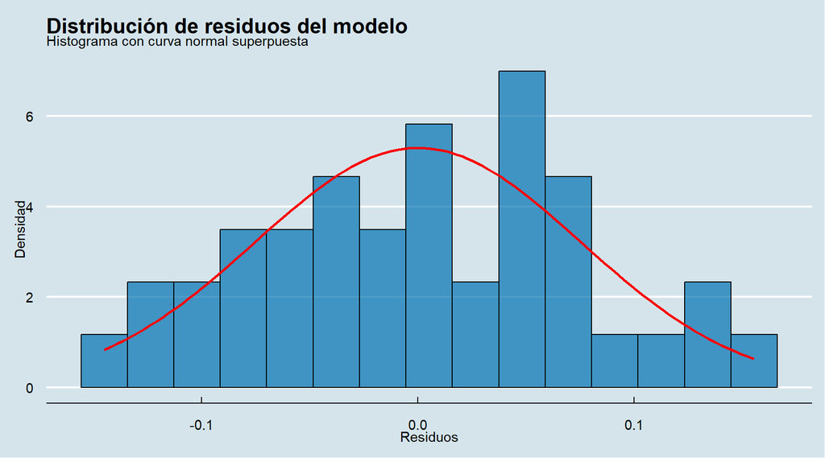

```r
residuos <- residuals(Eq_Mdmnd)

ggplot(data.frame(residuos), aes(x = residuos)) +
  geom_histogram(
    aes(y = after_stat(density)),
    bins  = 15,
    fill  = "#0072B2",
    color = "black",
    alpha = 0.7
  ) +
  stat_function(
    fun  = dnorm,
    args = list(mean = mean(residuos), sd = sd(residuos)),
    color = "red",
    linewidth = 1
  ) +
  labs(
    title    = "Distribución de residuos del modelo",
    subtitle = "Histograma con curva normal superpuesta",
    x        = "Residuos",
    y        = "Densidad"
  ) +
  theme_economist()
```

```r
jarque.bera.test(residuos)
```

```
##
##  Jarque Bera Test
##
## data:  residuos
## X-squared = 0.8436, df = 2, p-value = 0.6559
```

```r
shapiro.test(residuos)
```

```
##
##  Shapiro-Wilk normality test
##
## data:  residuos
## W = 0.98173, p-value = 0.7533
```

# 9 Conclusiones

[output not shown]

*Notebook generado en R Markdown — Fuente de datos: Gujarati D., Econometría, Tabla 17.3.*